# DATA 606 - Lab 3 - Probability

Preston Peck

2021-09-20

# Probability

https://htmlpreview.github.io/?https://github.com/jbryer/DATA606/blob/master/inst/labs/Lab3/Lab3_probability.html

```r
library(tidyverse)
library(openintro)
library(vctrs)
```

### Exercise 1

A streak of length one indicates that in a consecutive run of shots, starting with a miss, one shot is then made beginning a new consecutive shot count, which will then be followed by another miss, and so only one shot was made in a row.

A streak of zero indicates that in a run of consecutive shots, all shots are misses, so the consecutive shots made count is trapped at 0. The moment a shot is made, the streak starts beginning from 1. The moment a shot is then missed, the streak will return to 0, and that streak will remain the active streak until a shot is made.

### Exercise 2

Kobe’s typical shot streak length was 0, which means he missed more than he started hit streaks, however that doesn’t necessarily mean that he had more misses overall since one streak can represent many shots made within it. The longest streak he had was making 4 shots in a row.

```r
kobe_basket$shot
```

```
##   [1] "H" "M" "M" "H" "H" "M" "M" "M" "M" "H" "H" "H" "M" "H" "H" "M" "M" "H"
##  [19] "H" "H" "M" "M" "H" "M" "H" "H" "H" "M" "M" "M" "M" "M" "M" "H" "M" "H"
##  [37] "M" "M" "H" "H" "H" "H" "M" "H" "M" "M" "H" "M" "M" "H" "M" "M" "H" "M"
##  [55] "H" "H" "M" "M" "H" "M" "H" "H" "M" "H" "M" "M" "M" "H" "M" "M" "M" "M"
##  [73] "H" "M" "H" "M" "M" "H" "M" "M" "H" "H" "M" "M" "M" "M" "H" "H" "H" "M"
##  [91] "M" "H" "M" "M" "H" "M" "H" "H" "M" "H" "M" "M" "H" "M" "M" "M" "H" "M"
## [109] "H" "H" "H" "M" "H" "H" "H" "M" "H" "M" "H" "M" "M" "M" "M" "M" "M" "H"
## [127] "M" "H" "M" "M" "M" "M" "H"
```

```r
kobe_streak <- calc_streak(kobe_basket$shot)
kobe_streak
```

```
##    length
## 1       1
## 2       0
## 3       2
## 4       0
## 5       0
## 6       0
## 7       3
## 8       2
## 9       0
## 10      3
## 11      0
## 12      1
## 13      3
## 14      0
```

[output cut: 62 more lines]

```r
kobe_streak_counts <- vec_count(kobe_streak)
kobe_streak_count_totals <- apply(kobe_streak_counts, 1, function(x) x[1] * x[2])
kobe_streak_counts <- cbind(kobe_streak_counts, totals = kobe_streak_count_totals)
kobe_streak_counts
```

```
##   length count totals
## 1      0    39      0
## 2      1    24     24
## 3      2     6     12
## 4      3     6     18
## 5      4     1      4
```

```r
total_miss_streaks_and_hits <- data.frame(M_Streaks = kobe_streak_counts[1, 2], H = c(sum(kobe_streak_counts$total)))
total_miss_streaks_and_hits
```

```
##   M_Streaks  H
## 1        39 58
```

```r
total_misses_and_hits <- vec_count(kobe_basket$shot)
total_misses_and_hits
```

```
##   key count
## 1   M    75
## 2   H    58
```

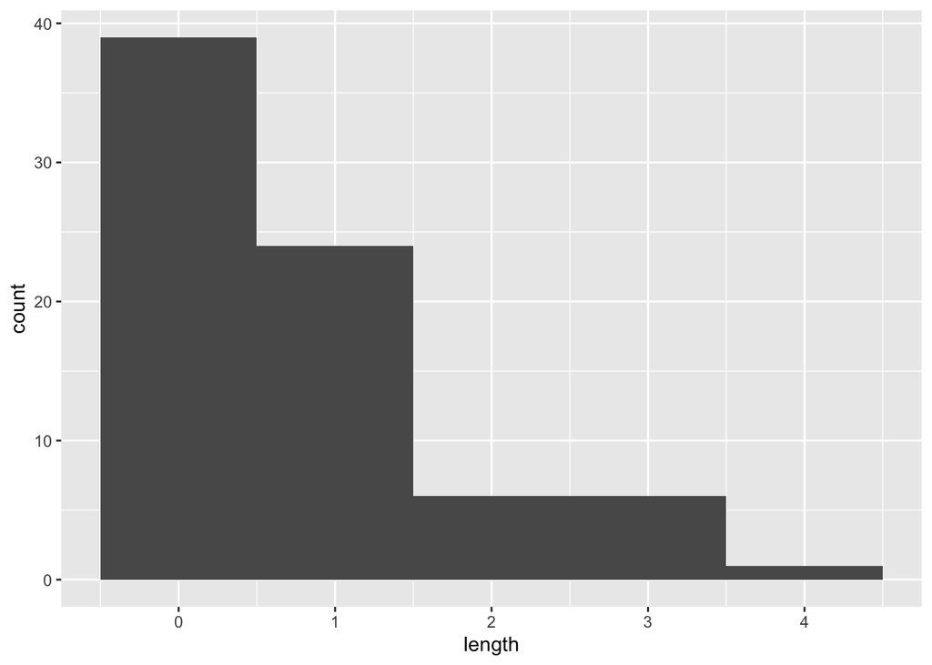

```r
ggplot(data = kobe_streak, aes(x = length)) +
  geom_histogram(binwidth = 1)
```

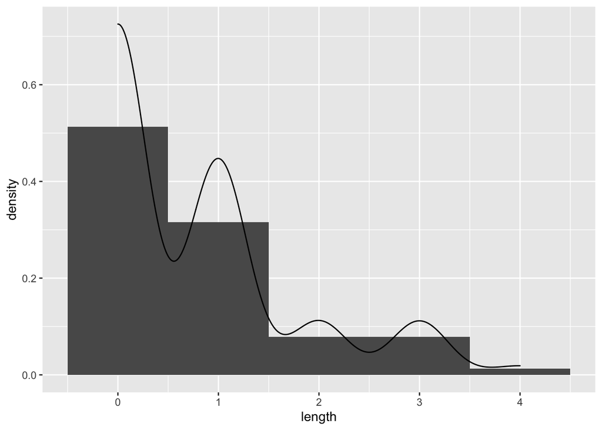

```r
ggplot(data = kobe_streak, aes(x = length)) +
  geom_histogram(binwidth = 1, aes(y = ..density..)) +
  geom_density()
```

### Exercise 3

```r
set.seed(37)
coin_outcomes <- c("heads", "tails")
sim_unfair_coin <- sample(coin_outcomes, size = 100, replace = TRUE, prob = c(0.2, 0.8))
vec_count(sim_unfair_coin)
```

```
##     key count
## 1 tails    79
## 2 heads    21
```

### Exercise 4

```r
shot_outcomes <- c("H", "M")
sim_basket <- sample(shot_outcomes, size = 133, replace = TRUE, c(0.45, .55))
sim_basket
```

```
##   [1] "H" "M" "H" "M" "H" "H" "H" "M" "H" "M" "H" "M" "M" "M" "M" "H" "H" "M"
##  [19] "M" "M" "H" "M" "M" "M" "M" "H" "H" "M" "M" "M" "H" "H" "M" "M" "H" "M"
##  [37] "H" "M" "M" "M" "M" "M" "M" "H" "H" "M" "M" "H" "M" "H" "H" "M" "H" "M"
##  [55] "M" "M" "H" "M" "H" "M" "M" "M" "M" "M" "M" "M" "M" "M" "H" "M" "M" "M"
##  [73] "M" "M" "H" "H" "M" "M" "M" "M" "M" "M" "M" "M" "M" "H" "H" "M" "M" "M"
##  [91] "H" "M" "M" "H" "M" "H" "M" "M" "H" "M" "H" "H" "H" "M" "M" "H" "H" "H"
## [109] "H" "M" "M" "M" "H" "M" "H" "M" "M" "H" "H" "M" "M" "M" "H" "M" "M" "M"
## [127] "H" "M" "H" "M" "M" "H" "H"
```

```r
vec_count(sim_basket)
```

```
##   key count
## 1   M    84
## 2   H    49
```

### Exercise 5

```r
sim_streak <- calc_streak(sim_basket)
sim_streak
```

```
##    length
## 1       1
## 2       1
## 3       3
## 4       1
## 5       1
## 6       0
## 7       0
## 8       0
## 9       2
## 10      0
## 11      0
## 12      1
## 13      0
## 14      0
```

[output cut: 71 more lines]

```r
total_misses_and_hits <- vec_count(sim_basket)
total_misses_and_hits
```

```
##   key count
## 1   M    84
## 2   H    49
```

### Exercise 6

The independent player’s typical shot streak length was 0, which means he missed more than he started hit streaks. The longest streak they had was making 4 shots in a row.

```r
sim_streak_counts <- vec_count(sim_streak)
sim_streak_counts
```

```
##   length count
## 1      0    52
## 2      1    21
## 3      2     9
## 4      3     2
## 5      4     1
```

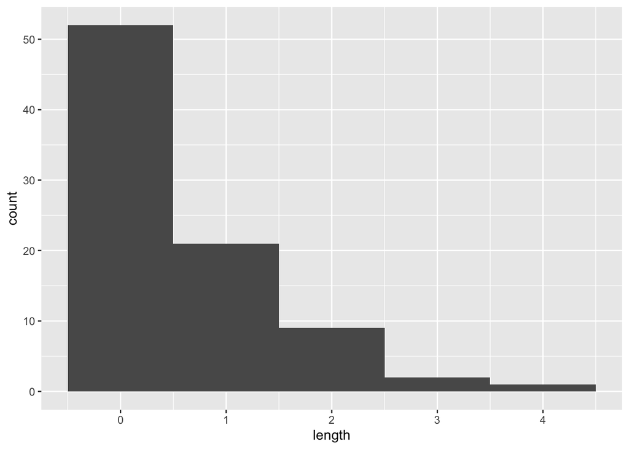

```r
ggplot(data = sim_streak, aes(x = length)) +
  geom_histogram(binwidth = 1)
```

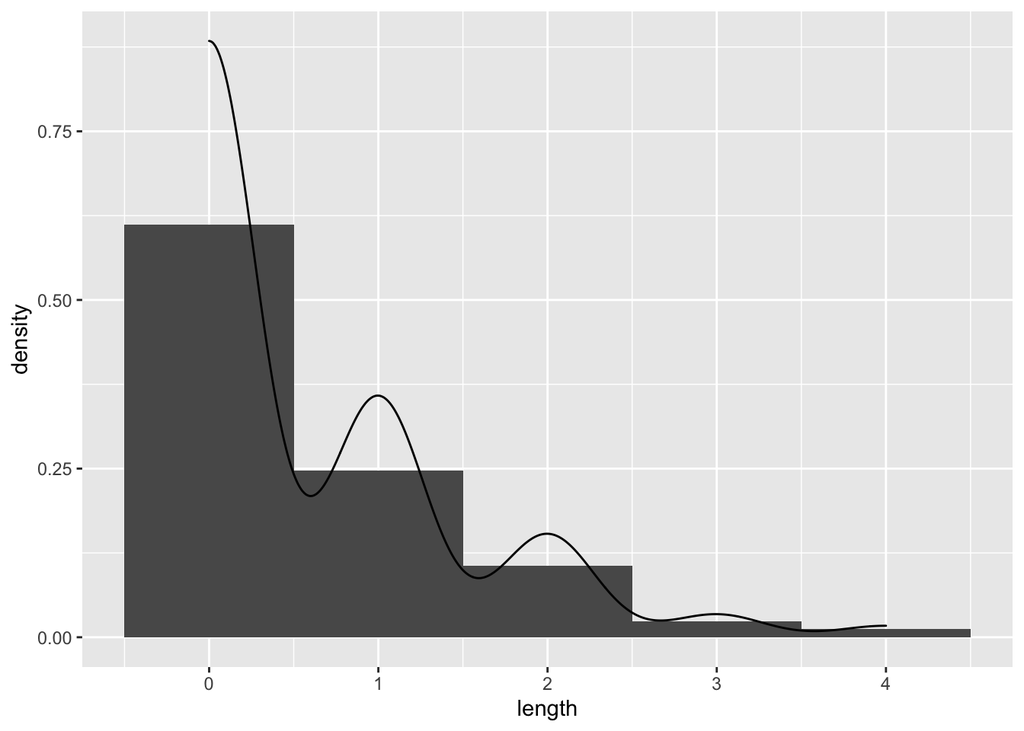

```r
ggplot(data = sim_streak, aes(x = length)) +
  geom_histogram(binwidth = 1, aes(y = ..density..)) +
  geom_density()
```

### Exercise 7

If we were to run this simulation again, we can expect this simulation to return a somewhat similar result (if we factor in the seed, it would be exactly the same). The sample size is large enough that the initial percentages can be adquately expressed.